# New Plots 5-17

### Montevideo BFD/non-focalized graphs:

**Graph 1: Montevideo BFD nuclear configurations (i.e., pitch accent + boundary tone) (not by Gender or age).**

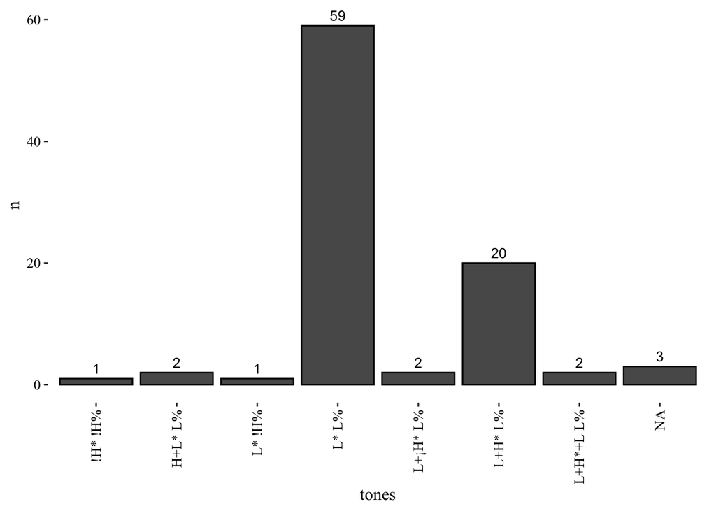

> Graph 1: A poisson regression was run where the dependent variable was n (number of occurrences) and the independent variable was tone (only the tones L*L% and L+H*L& were included). The model revealed a significant difference between these two levels (β = -1.08; p < .05).

**Graph 2: Montevideo non-focalized prenuclear pitch accents (combined count of prenuclear BFD and prenuclear non-focalized NFD PWs) (not by gender or age). Exclude L* and any pitch accent followed by an ip boundary tone L-, H-, !H-.**

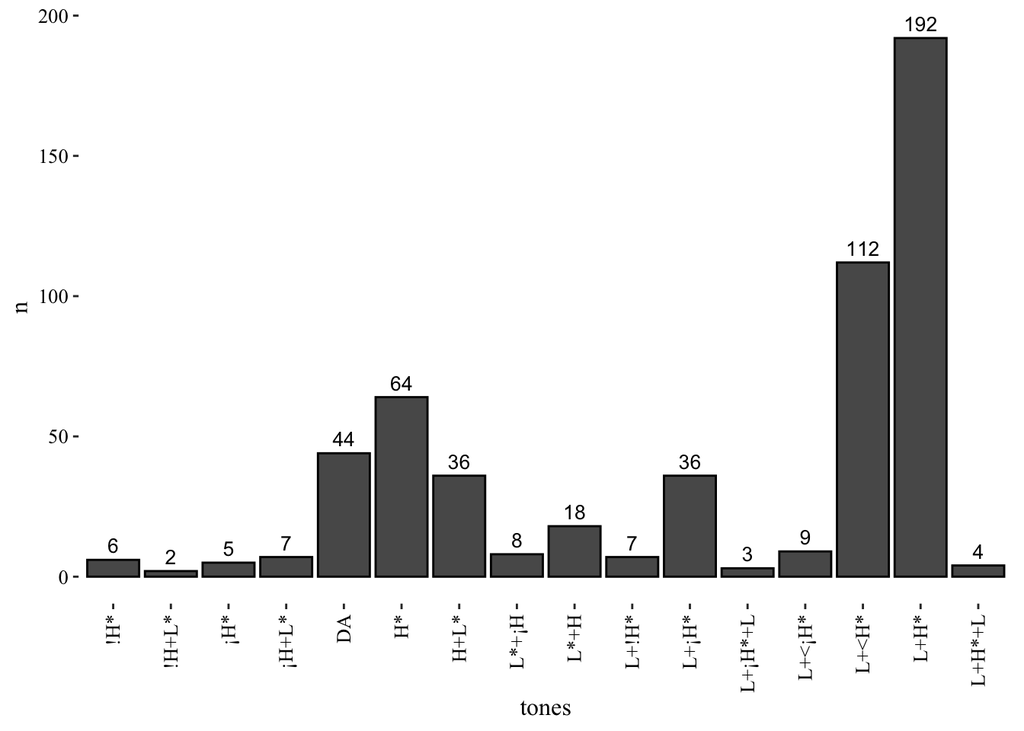

> An additional post-hoc test comparing L+H* and L+<H* found a significant difference in a poisson regression (β = .54, p < .0005).

Table 1: Model forMontevideo non-focalized prenuclear pitch accents

|  | Estimate | Std. Error | z value | p value |
| --- | --- | --- | --- | --- |
| (Intercept) | 3.78 | 0.15 | 25.10 | 0 |
| tonesH* | 0.37 | 0.20 | 1.91 | 0.06 |
| tonesH+L* | -0.20 | 0.22 | -0.89 | 0.37 |
| tonesL+¡H* | -0.20 | 0.22 | -0.89 | 0.37 |
| tonesL+<H* | 0.93 | 0.18 | 5.25 | 0 |
| tonesL+H* | 1.47 | 0.17 | 8.81 | 0 |

**Graph 3: Montevideo BFD nuclear configurations (i.e., pitch accents + boundary tones) by Gender. Like you already provided but this time labeled Gender.**

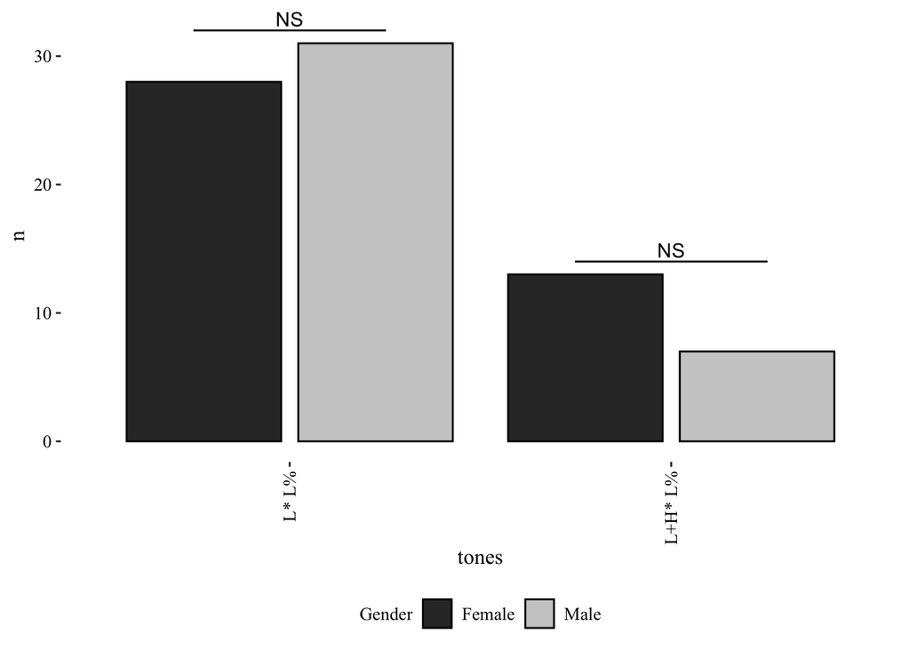

> Graph 3: The comparisons here were poisson regressions where the dependent variable in each case was the number of productions and the inpendent variable was Gender (2 levels).

**Graph 4: Montevideo non-focalized prenuclear pitch accents (combined count of prenuclear BFD and prenuclear non-focalized NFD PWs)… Like Graph 2 but by Gender.**

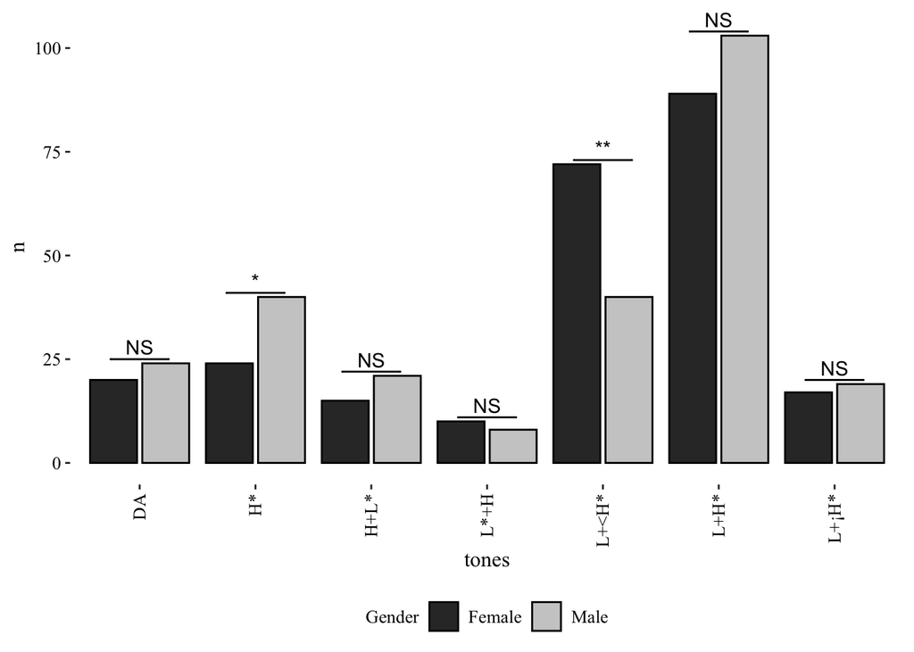

> Graph 4: The comparisons here were poisson regressions where the dependent variable in each case was the number of productions and the inpendent variable was Gender (2 levels).

**Graph 5: Montevideo BFD nuclear configurations (i.e., pitch accents + boundary tones) by age.**

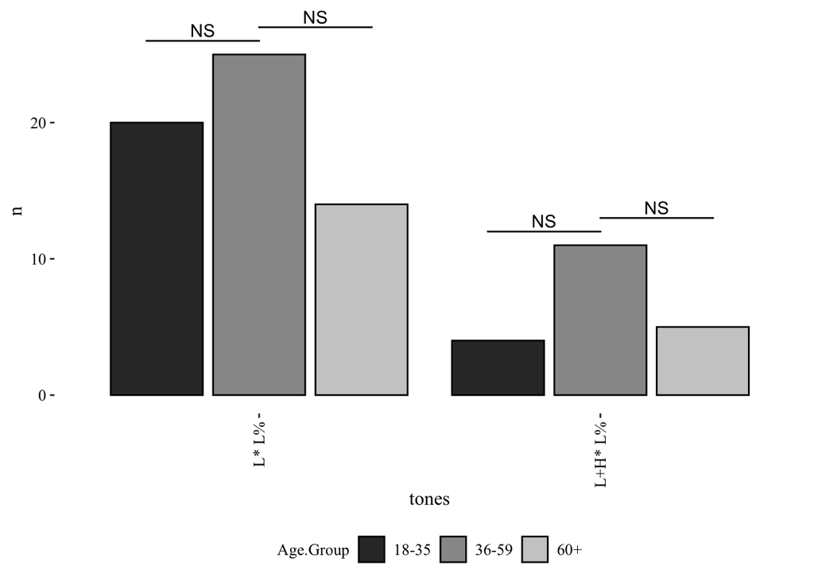

> Graph 5: The comparisons here were poisson regressions where the dependent variable in each case was the number of productions and the inpendent variable was age (3 levels).

**Graph 6: Montevideo non-focalized prenuclear pitch accents (combined count of prenuclear BFD and prenuclear non-focalized NFD PWs)… Like Graph 4 but by age.**

```
## [1] "*"
## [1] "*"
## [1] "*"
## [1] "*"
```

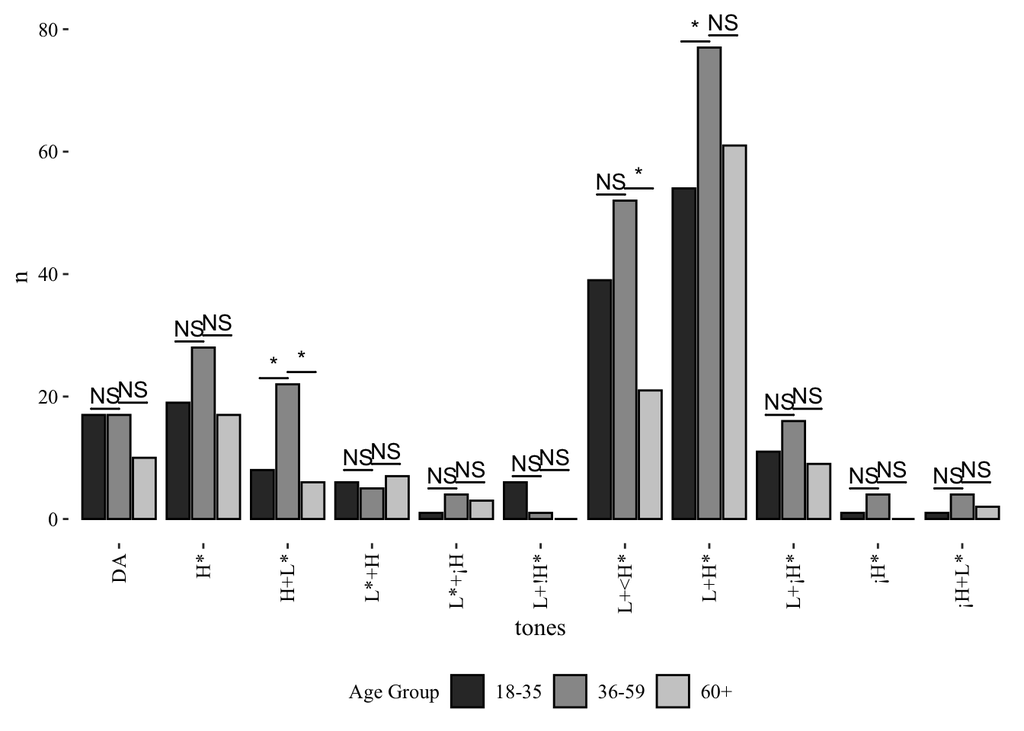

**Graph 7a: Montevideo focalized NFDs including pitch accents + boundary tones (like the graph you provided but only for Montevideo) (not by Gender or age).**

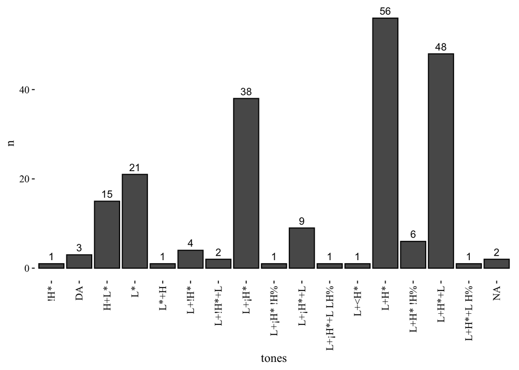

**Graph 7b: Montevideo focalized NFDs including pitch accents + boundary tones by Gender.**

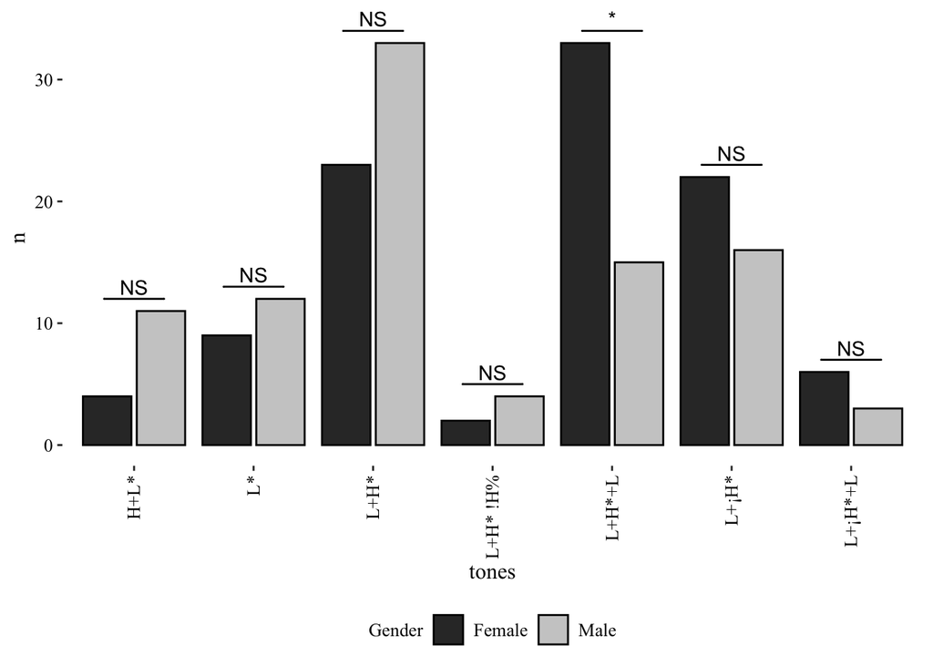

**Graph 7c: Montevideo focalized NFDs including pitch accents + boundary tones by age**

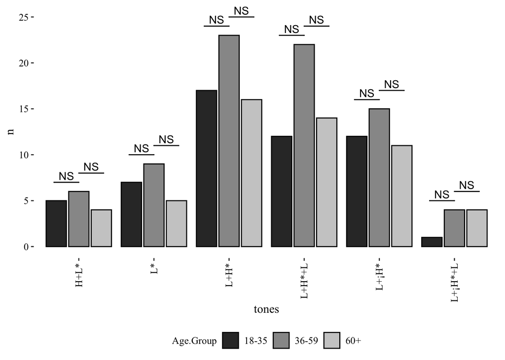

**Graph 8a-c Montevideo NFD Focused Pitch Accents and Boundary tones for NFD1. Trimmed**

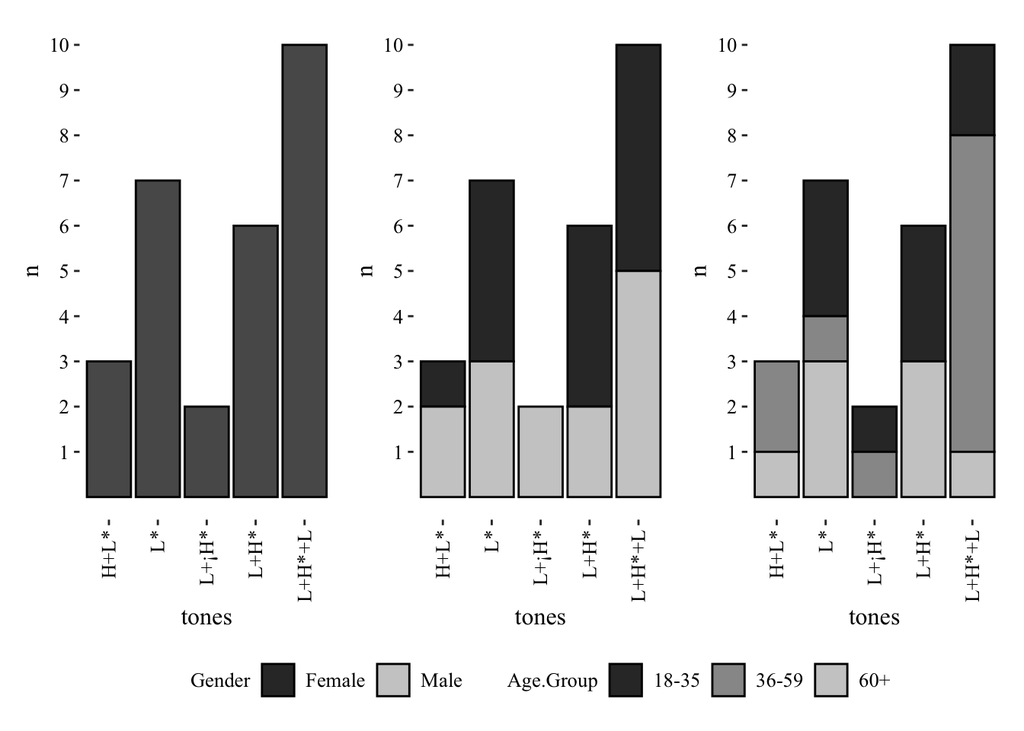

A summary of Gender poisson regressions for Montevideo NFD1

| tones | p_value | result |
| --- | --- | --- |
| H+L* | 0.5714249 | NS |
| L* | 0.7064231 | NS |
| L+H* | 0.4234920 | NS |
| L+H*+L | 1.0000000 | NS |
| L+¡H* | 0.9995657 | NS |

A summary of age poisson regressions for Montevideo NFD1

| tones | p_value_18_35 | p_value_60 |
| --- | --- | --- |
| L* | NS | NS |
| L+H* | NT | NT |
| L+H*+L | NS | NS |
| L+¡H* | NS | NS |
| H+L* | NS | NS |

**Graph 9a-c Montevideo NFD Focused Pitch Accents and Boundary tones for NFD2. Trimmed**

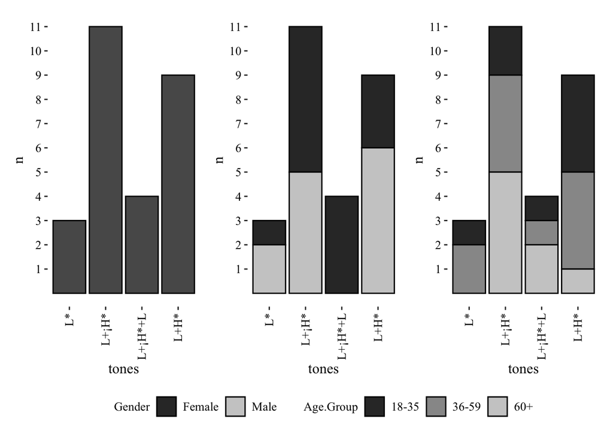

A summary of Gender poisson regressions for Montevideo NFD2

| tones | p_value | result |
| --- | --- | --- |
| L* | 0.5714249 | NS |
| L+H* | 0.3269587 | NS |
| L+¡H* | 0.7633427 | NS |
| L+¡H*+L | 0.9995526 | NS |

A summary of age poisson regressions for Montevideo NFD2

| tones | p_value_18_35 | p_value_60 |
| --- | --- | --- |
| L* | NS | NS |
| L+H* | NS | NS |
| L+¡H* | NS | NS |
| L+¡H*+L | NS | NS |

**Graph 10a-c Montevideo NFD Focused Pitch Accents and Boundary tones for NFD3 - No. Trimmed**

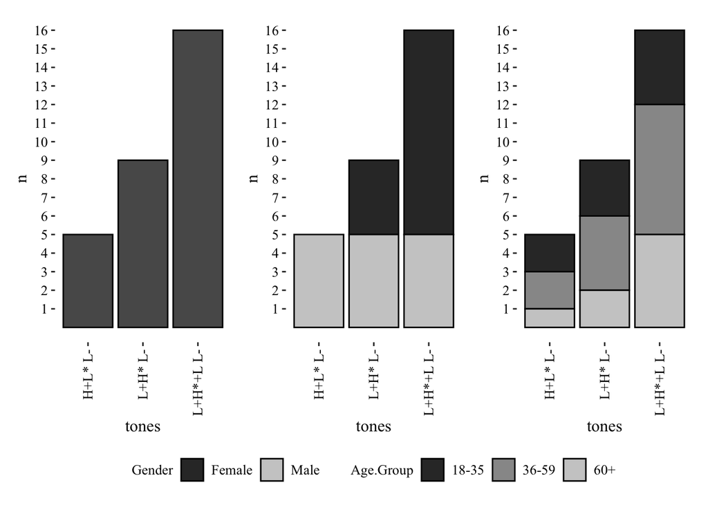

A summary of Gender poisson regressions for Montevideo NFD3 no

[output not shown]

A summary of age poisson regressions for Montevideo NFD3 no

| tones | p_value_18_35 | p_value_60 |
| --- | --- | --- |
| H+L* L- | NS | NS |
| L+H* L- | NS | NS |
| L+H*+L L- | NS | NS |

**Graph 10d-f Montevideo NFD Focused Pitch Accents and Boundary tones for NFD3 - a San Juan. Trimmed**

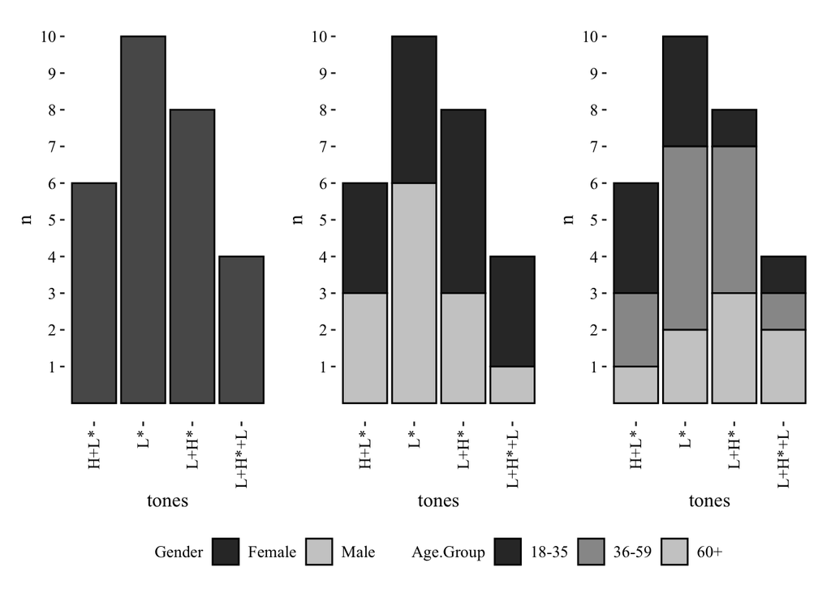

A summary of Gender poisson regressions for Montevideo NFD3 a San Juan

| tones | p_value | result |
| --- | --- | --- |
| H+L* | 1.0000000 | NS |
| L* | 0.5299097 | NS |
| L+H* | 0.4842541 | NS |
| L+H*+L | 0.3413863 | NS |

A summary of age poisson regressions for Montevideo NFD3 a San Juan

| tones | p_value_18_35 | p_value_60 |
| --- | --- | --- |
| H+L* | NS | NS |
| L* | NS | NS |
| L+H* | NS | NS |
| L+H*+L | NS | NS |

**Graph 11a-c Montevideo NFD Focused Pitch Accents and Boundary tones for NFD4. Trimmed**

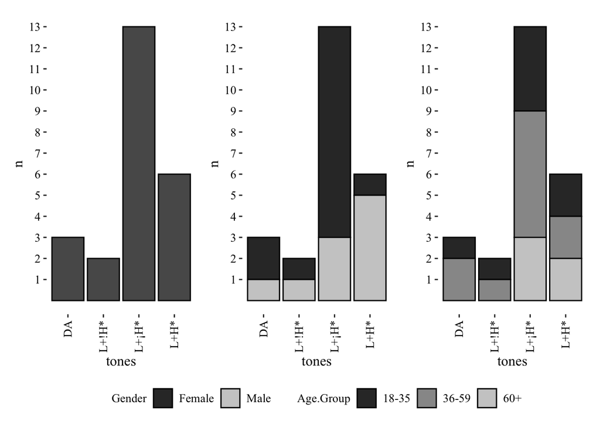

A summary of Gender poisson regressions for Montevideo NFD4

| tones | p_value | result |
| --- | --- | --- |
| DA | 0.5714249 | NS |
| L+!H* | 1.0000000 | NS |
| L+H* | 0.1417745 | NS |
| L+¡H* | 0.0674047 | NS |

A summary of age poisson regressions for Montevideo NFD4

| tones | p_value_18_35 | p_value_60 |
| --- | --- | --- |
| DA | NS | NS |
| L+!H* | NS | NS |
| L+H* | NS | NS |
| L+¡H* | NS | NS |

**Graph 12a-c Montevideo NFD Focused Pitch Accents and Boundary tones for NFD5. Trimmed**

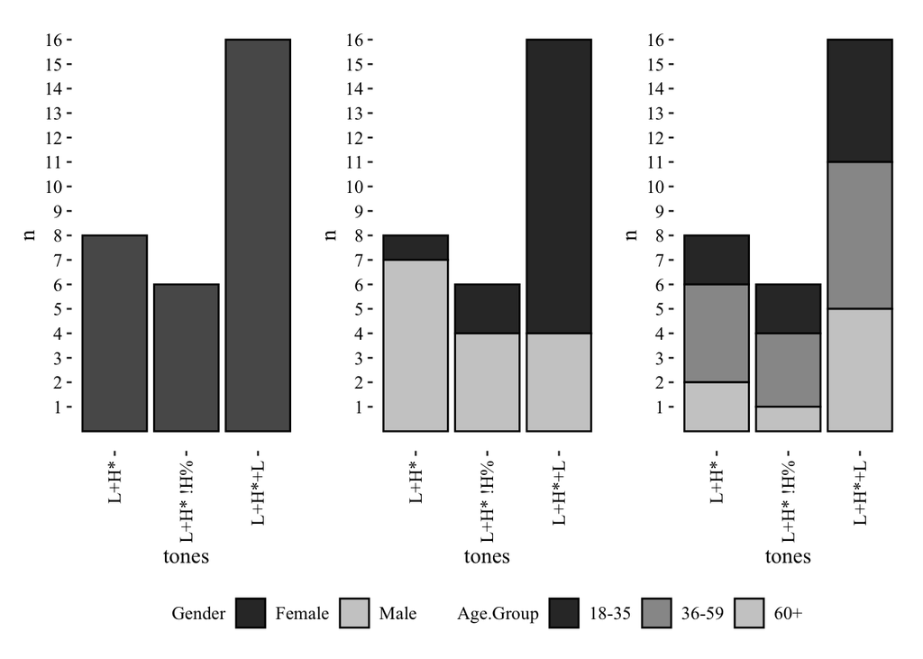

A summary of Gender poisson regressions for Montevideo NFD5

| tones | p_value | result |
| --- | --- | --- |
| L+H* | 0.0687225 | NS |
| L+H* !H% | 0.4234920 | NS |
| L+H*+L | 0.0570598 | NS |

A summary of age poisson regressions for Montevideo NFD5

| tones | p_value_18_35 | p_value_60 |
| --- | --- | --- |
| L+H* | NS | NS |
| L+H* !H% | NS | NS |
| L+H*+L | NS | NS |

**Graph 13a-c Montevideo NFD Focused Pitch Accents and Boundary tones for NFD6. Trimmed**

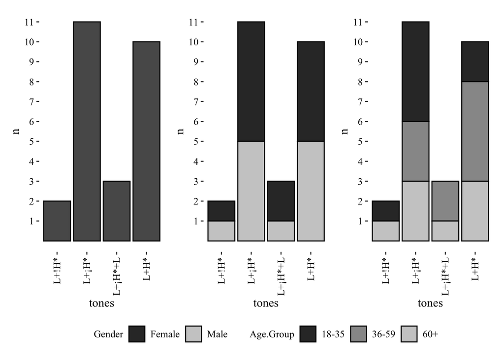

A summary of Gender poisson regressions for Montevideo NFD6

| tones | p_value | result |
| --- | --- | --- |
| L+!H* | 1.0000000 | NS |
| L+H* | 1.0000000 | NS |
| L+¡H* | 0.7633427 | NS |
| L+¡H*+L | 0.5714249 | NS |

A summary of age poisson regressions for Montevideo NFD6

| tones | p_value_18_35 | p_value_60 |
| --- | --- | --- |
| L+!H* | NT | NT |
| L+H* | NS | NS |
| L+¡H* | NS | NS |
| L+¡H*+L | NS | NS |

### Durazno BFD/non-focalized graphs:

**Graph 14: Durazno BFD nuclear configurations (i.e., pitch accent + boundary tone) (not by Gender or age).**

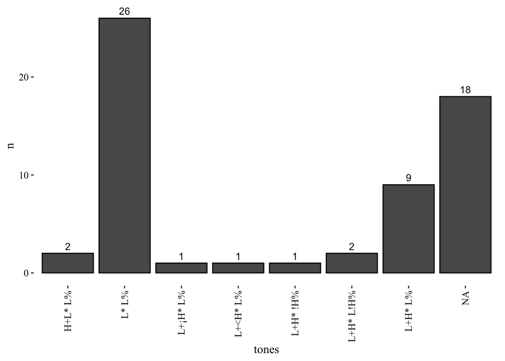

> Graph 14: A poisson regression was run where the dependent variable was n (number of occurrences) and the independent variable was tone (the tones L*L% and L+H*L% and N/A were included). The model revealed a significant difference between L*L% and L+H*L% two levels (β = -1.06; p < .05). and between L*L% but not N/A (-0.37; p = .23).

**Graph 15: Durazno non-focalized prenuclear pitch accents (combined count of prenuclear BFD and prenuclear non-focalized NFD PWs)**

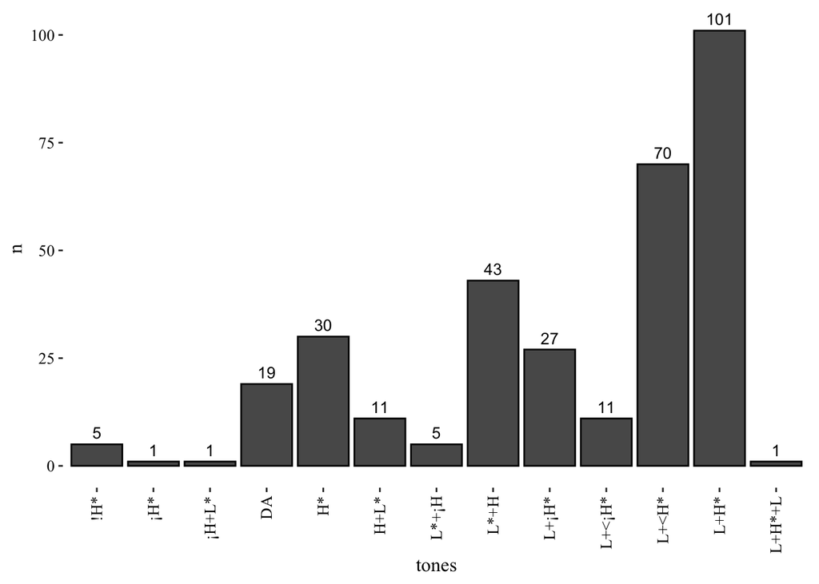

> Graph 15: A poisson regression was run where the dependent variable was n (number of occurrences) and the independent variable was tone (3 levels for this model: L*+H, L+<H* and L+H*). The intercept of the model is L*+H, so, like the model for Montevideo, all differences which are significant only tell us that these two pitch accents are predicted by the model to be produced significantly more than L*+H tokens.

> An additional post-hoc test comparing L+H* and L+<H* found a significant difference in a poisson regression (β = .37, p < .05).

|  | Estimate | Std. Error | z value | p value |
| --- | --- | --- | --- | --- |
| (Intercept) | 3.76 | 0.15 | 24.66 | **< .005*** |
| tonesL+<H* | 0.49 | 0.19 | 2.51 | *< .05** |
| tonesL+H* | 0.85 | 0.18 | 4.69 | **< .005*** |

```
##
## Call:
## glm(formula = n ~ tones, family = poisson(link = "log"), data = postdf_2)
##
## Coefficients:
##             Estimate Std. Error z value Pr(>|z|)
## (Intercept)   4.2485     0.1195  35.545   <2e-16 ***
## tonesL+H*     0.3666     0.1555   2.357   0.0184 *
## ---
## Signif. codes:  0 '***' 0.001 '**' 0.01 '*' 0.05 '.' 0.1 ' ' 1
##
## (Dispersion parameter for poisson family taken to be 1)
##
##     Null deviance:  5.6511e+00  on 1  degrees of freedom
## Residual deviance: -9.7700e-15  on 0  degrees of freedom
## AIC: 16.543
##
## Number of Fisher Scoring iterations: 2
```

> **Graph 16: Durazno BFD nuclear configurations (i.e., pitch accents + boundary tones) by Gender. Like you already provided but this time labeled Gender.**

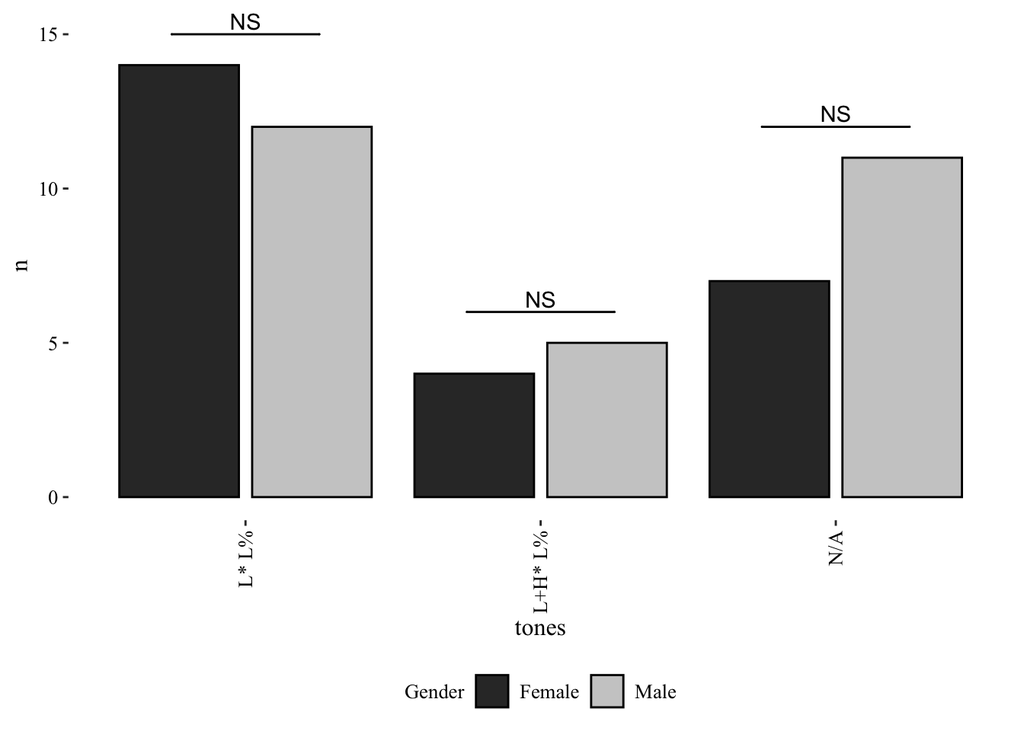

> Graph 16: The comparisons here were poisson regressions where the dependent variable in each case was the number of productions and the inpendent variable was Gender (2 levels).

**Graph 17: Durazno non-focalized prenuclear pitch accents (combined count of prenuclear BFD and prenuclear non-focalized NFD PWs)… Like Graph 2 but by Gender.**

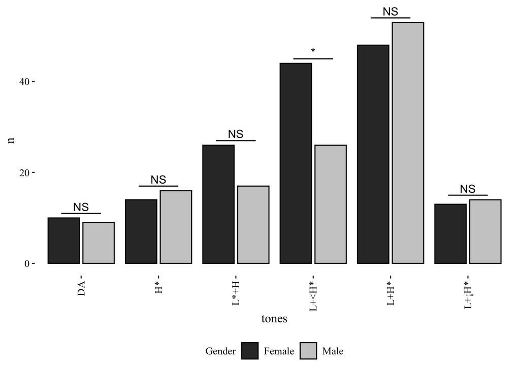

> Graph 17: The comparisons here were poisson regressions where the dependent variable in each case was the number of productions and the inpendent variable was Gender (2 levels).

**Graph 18: Durazno BFD nuclear configurations (i.e., pitch accents + boundary tones) by age.**

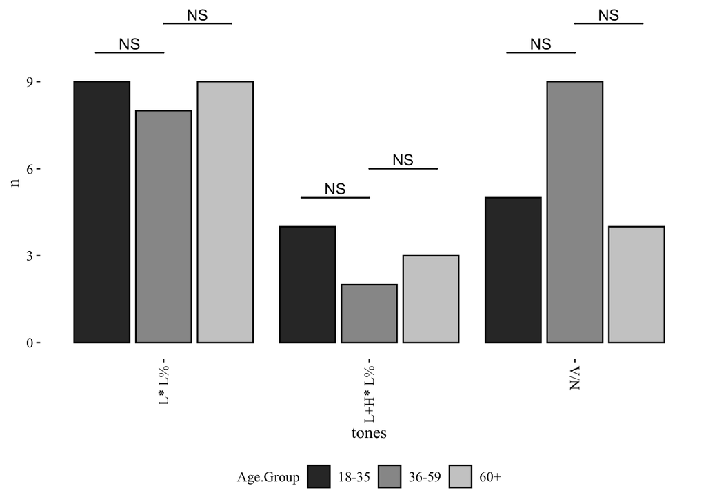

**Graph 19: Durazno non-focalized prenuclear pitch accents (combined count of prenuclear BFD and prenuclear non-focalized NFD PWs)… Like Graph 4 but by age.**

```
## [1] "*"
```

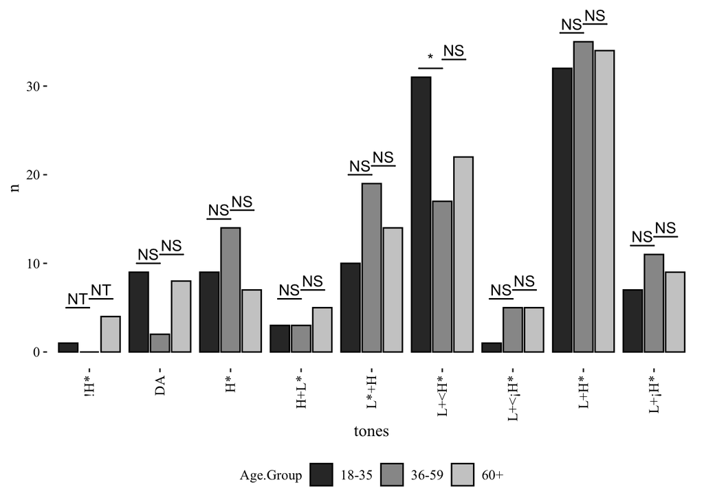

**Graph 20a: Durazno focalized NFDs including pitch accents + boundary tones (like the graph you provided but only for Durazno) (not by Gender or age).**

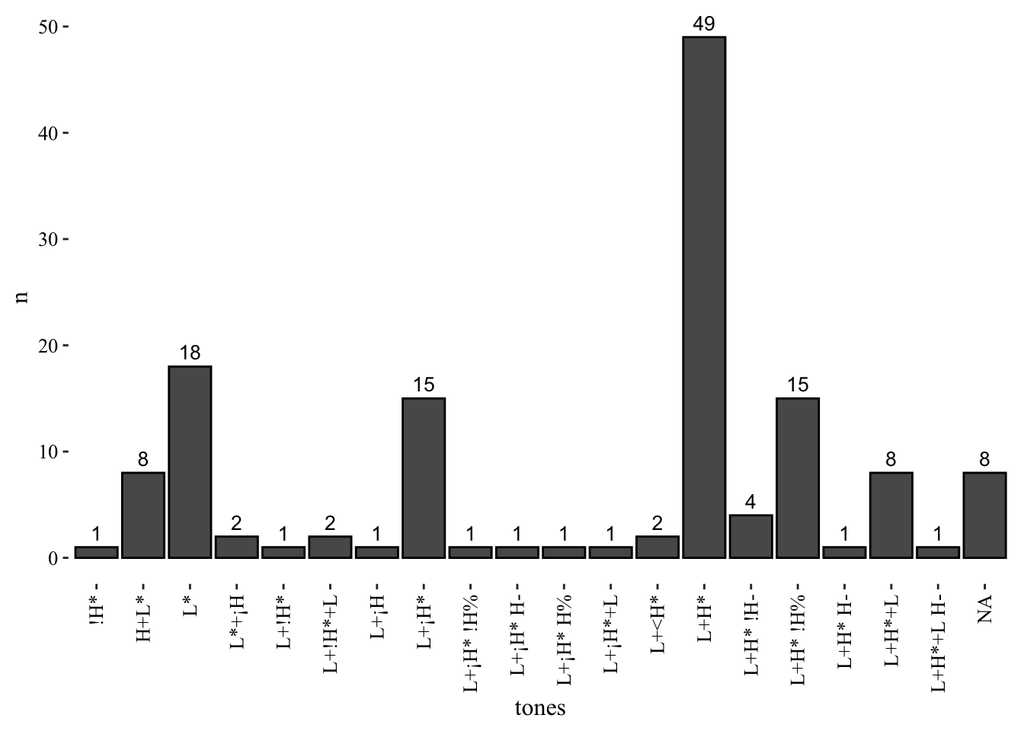

**Graph 20b: Durazno focalized NFDs including pitch accents + boundary tones by Gender.**

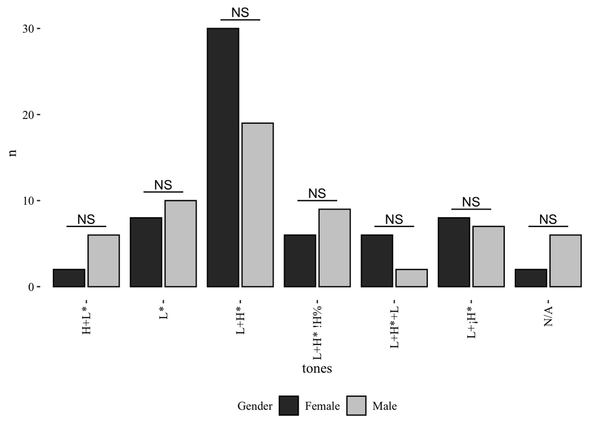

**Graph 20c: Durazno focalized NFDs including pitch accents + boundary tones by age**

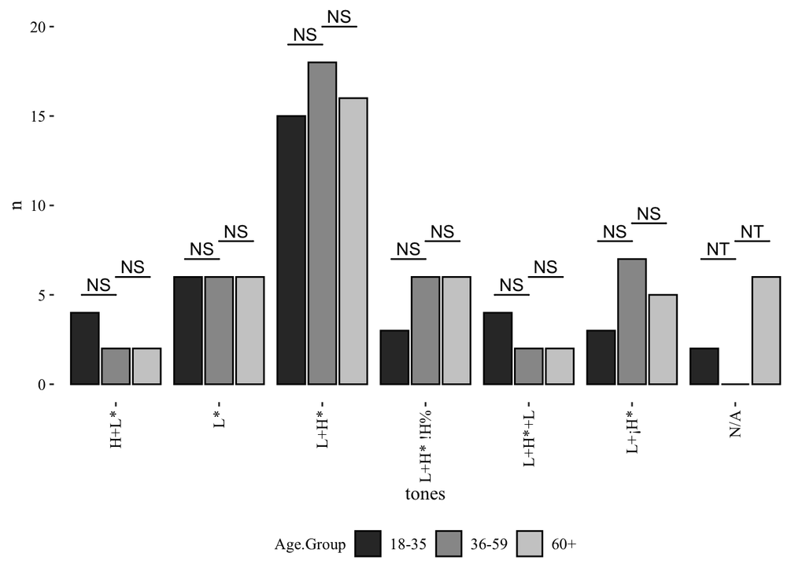

**Graph 21a-c Durazno NFD Focused Pitch Accents and Boundary tones for NFD1. Trimmed**

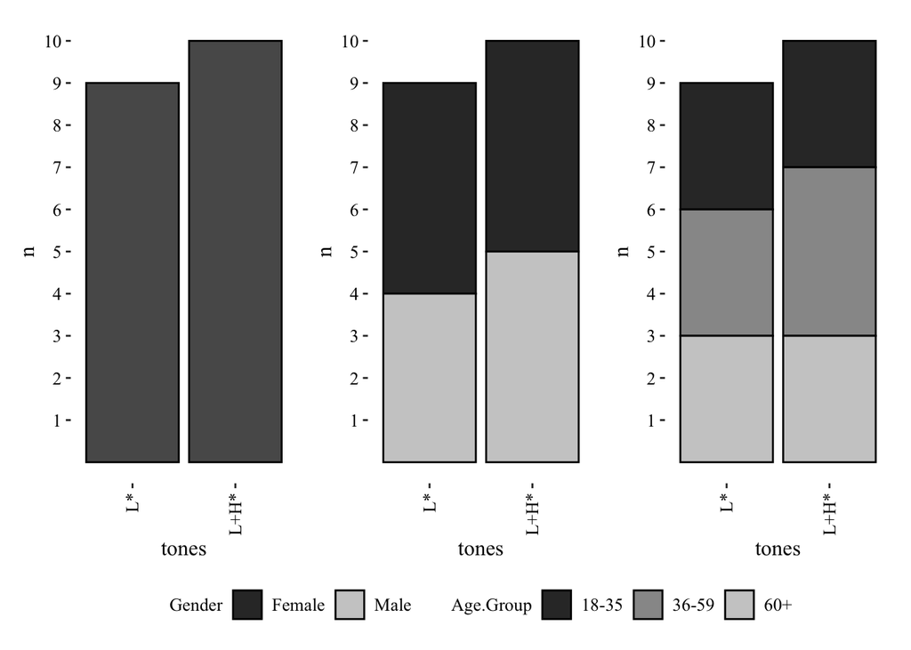

A summary of Gender poisson regressions for Durazno NFD1

| tones | p_value | result |
| --- | --- | --- |
| L* | 0.739404 | NS |
| L+H* | 1.000000 | NS |

A summary of age poisson regressions for Durazno NFD1

| tones | p_value_18_35 | p_value_60 |
| --- | --- | --- |
| L* | NS | NS |
| L+H* | NS | NS |

**Graph 22a-c Durazno NFD Focused Pitch Accents and Boundary tones for NFD2. Trimmed**

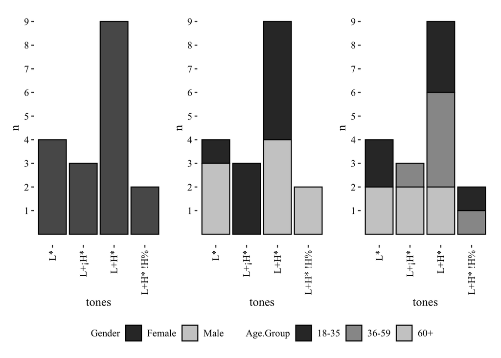

A summary of Gender poisson regressions for Durazno NFD2

| tones | p_value | result |
| --- | --- | --- |
| L* | 0.3413863 | NS |
| L+H* | 0.7394040 | NS |
| L+¡H* | 0.9995580 | NS |
| L+H* !H% | 0.9995657 | NS |

A summary of age poisson regressions for Durazno NFD2

| tones | p_value_18_35 | p_value_60 |
| --- | --- | --- |
| L* | NT | NT |
| L+H* | NS | NS |
| L+H* !H% | NS | NS |
| L+¡H* | NS | NS |

**Graph 23a-c Durazno NFD Focused Pitch Accents and Boundary tones for NFD3 - No. Trimmed**

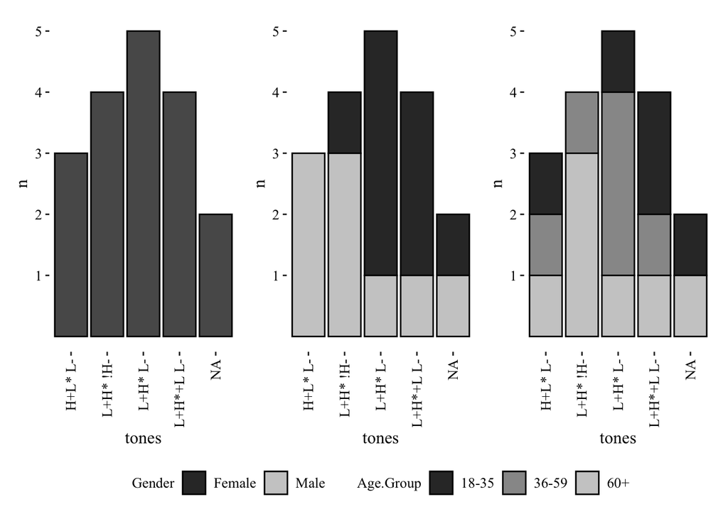

A summary of Gender poisson regressions for Durazno NFD3 no

[output not shown]

A summary of age poisson regressions for Durazno NFD3 no

| tones | p_value_18_35 | p_value_60 |
| --- | --- | --- |
| H+L* L- | NS | NS |
| L+H* L- | NS | NS |
| L+H*+L L- | NS | NS |
| N/A | NT | NT |
| L+H* !H- | NS | NS |

**Graph 23d-f Durazno NFD Focused Pitch Accents and Boundary tones for NFD3 - a San Juan. Trimmed**

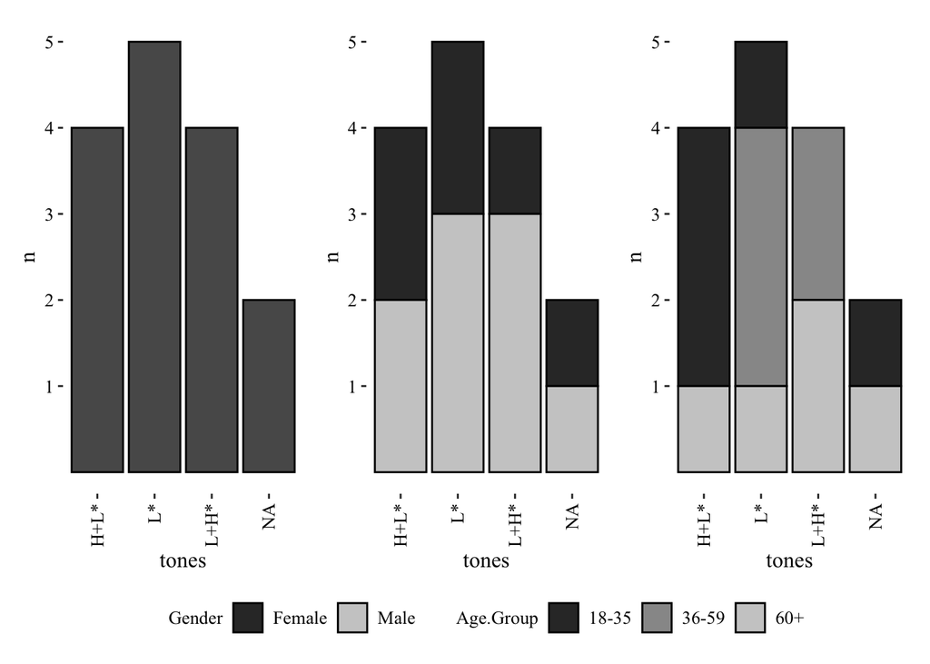

A summary of Gender poisson regressions for Durazno NFD3 a San Juan

| tones | p_value | result |
| --- | --- | --- |
| H+L* | 1.0000000 | NS |
| L* | 0.6569234 | NS |
| L+H* | 0.3413863 | NS |
| N/A | 1.0000000 | NS |

A summary of age poisson regressions for Durazno NFD3 a San Juan

| tones | p_value_18_35 | p_value_60 |
| --- | --- | --- |
| H+L* | NT | NT |
| L* | NS | NS |
| N/A | NT | NT |
| L+H* | NS | NS |

**Graph 24a-c Durazno NFD Focused Pitch Accents and Boundary tones for NFD4. Trimmed**

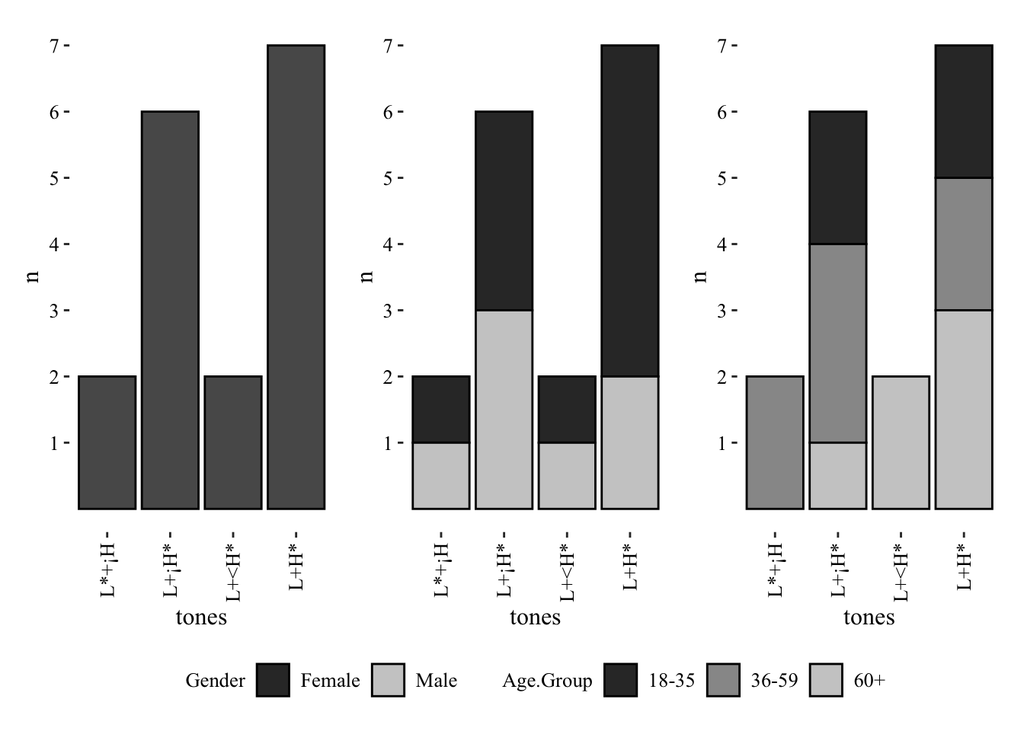

A summary of Gender poisson regressions for Durazno NFD4

| tones | p_value | result |
| --- | --- | --- |
| L*+¡H | 1.000000 | NS |
| L+<H* | 1.000000 | NS |
| L+H* | 0.273439 | NS |
| L+¡H* | 1.000000 | NS |

A summary of age poisson regressions for Durazno NFD4

| tones | p_value_18_35 | p_value_60 |
| --- | --- | --- |
| L+H* | NS | NS |
| L+¡H* | NS | NS |
| L*+¡H | NS | NS |
| L+<H* | NT | NT |

**Graph 25a-c Durazno NFD Focused Pitch Accents and Boundary tones for NFD5. Trimmed**

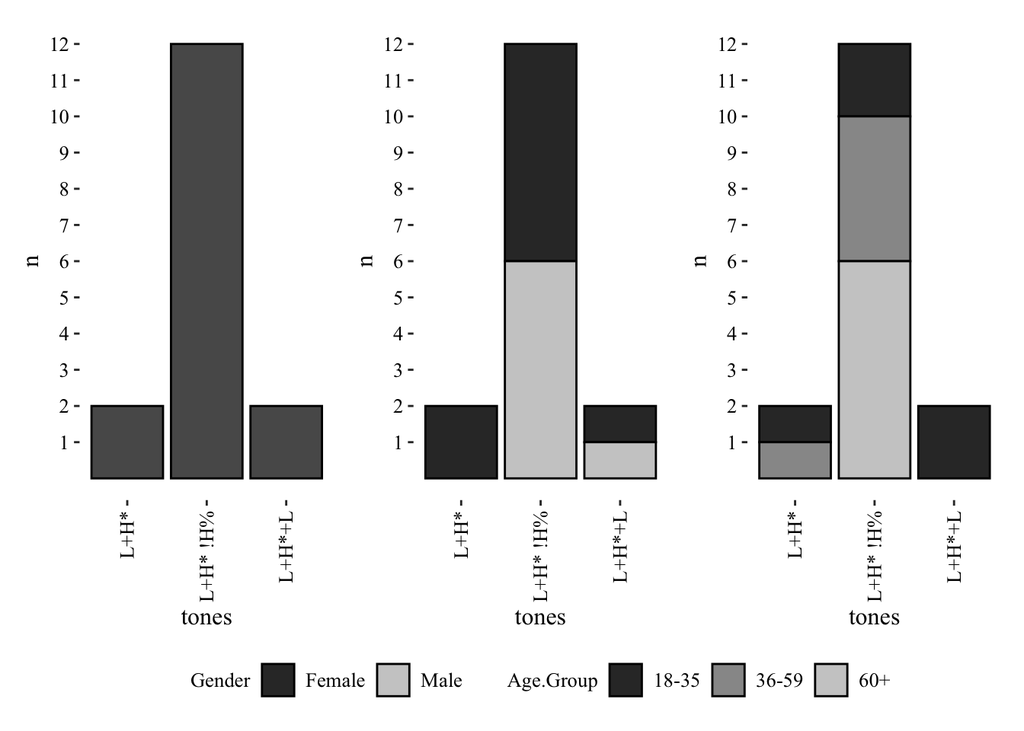

A summary of Gender poisson regressions for Durazno NFD5

| tones | p_value | result |
| --- | --- | --- |
| L+H* | 0.9995657 | NS |
| L+H* !H% | 1.0000000 | NS |
| L+H*+L | 1.0000000 | NS |

A summary of age poisson regressions for Durazno NFD5

| tones | p_value_18_35 | p_value_60 |
| --- | --- | --- |
| L+H* | NS | NS |
| L+H* !H% | NS | NS |
| L+H*+L | NT | NT |

**Graph 26a-c Durazno NFD Focused Pitch Accents and Boundary tones for NFD6. Trimmed**

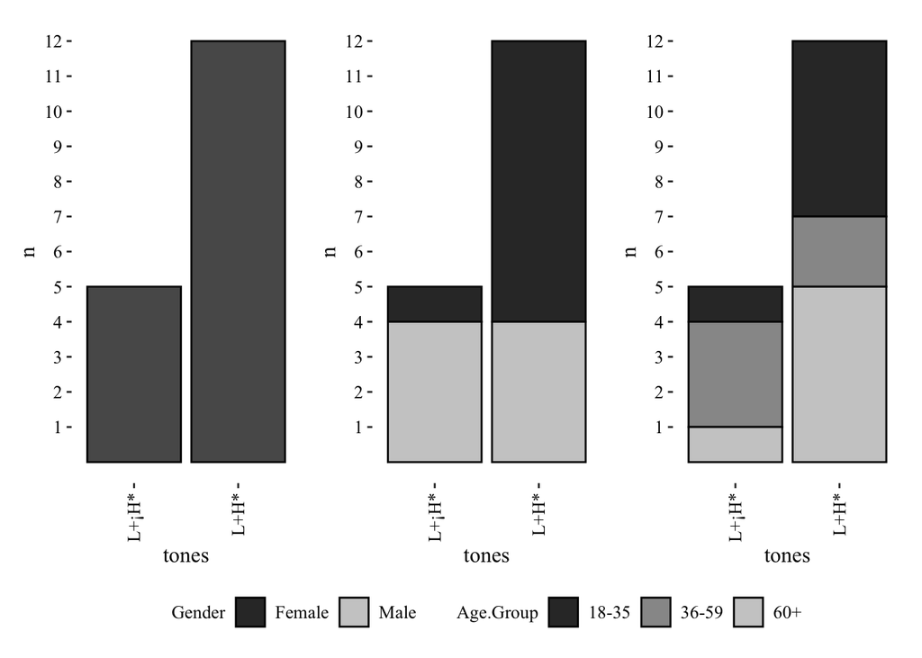

A summary of Gender poisson regressions for Durazno NFD6

| tones | p_value | result |
| --- | --- | --- |
| L+H* | 0.2576745 | NS |
| L+¡H* | 0.2149960 | NS |

A summary of age poisson regressions for Durazno NFD6

| tones | p_value_18_35 | p_value_60 |
| --- | --- | --- |
| L+H* | NS | NS |
| L+¡H* | NS | NS |